# Dynamic Econometric Models

Jared Connor

May 2, 2018

This small tutorial is going to be an introduction to dynamic econometric models based upon the [Applied Econometric (ECON 508)](http://www.econ.uiuc.edu/~econ508/R/e-ta3_R.html) course from Illinois. The hope is to understanding these modeling techniques from an applied perspective to utilize in further projects.

[Distributed lag models](http://www.reed.edu/economics/parker/312/tschapters/S13_Ch_3.pdf) are a powerful set of econometric models that allow us to capture the time dependent effects of systems that a static linear or time series model lack. For example, if we are attempting to view the effects of a company moving into a metropolitan area on local wages, it would make sense that wages wouldn’t directly increase immediately after the event. In realitly, a gradual increase in wages would be observed. Attempting to view the number of period (**or lags**) that this takes is exactly the tool required to understand the lasting effects of these events.

### Data Set:

We’re going to be utilizing the data borrowed from Johnston and Dinardo’s Econometric Methods (1997, 4th ed).

```r
auto <- read.table("http://www.econ.uiuc.edu/~econ508/data/AUTO2.txt", header = TRUE)
kable(head(auto))
```

| quarter | gas | price | income | miles |
| --- | --- | --- | --- | --- |
| 1959.1 | -8.015248 | 4.675750 | -4.505240 | 2.647592 |
| 1959.2 | -8.011060 | 4.691292 | -4.492739 | 2.647592 |
| 1959.3 | -8.019878 | 4.689134 | -4.498873 | 2.647592 |
| 1959.4 | -8.012581 | 4.722338 | -4.491904 | 2.647592 |
| 1960.1 | -8.016769 | 4.707470 | -4.490103 | 2.647415 |
| 1960.2 | -7.976376 | 4.699136 | -4.489107 | 2.647238 |

Now we have to define our variables of interest. What we are doing here is defining these columns in the `auto` dataframe to *time series* objects in R. These are specifically used to allow for regressions and models that incorporate lags and leads, auto/partial correlation plots, and other time related aspects that are quite handy. We could, if we wanted to, dive quite farther into the time related objects in R, but for brevetiy, I tend to use this as a reference: [Dates and Times in R](https://www.stat.berkeley.edu/~s133/dates.html).

```r
gas <- ts(auto$gas, start = 1959, frequency = 4)
price <- ts(auto$price, start = 1959, frequency = 4)
income <- ts(auto$income, start = 1959, frequency = 4)
miles <- ts(auto$miles, start = 1959, frequency = 4)
```

Let’s view and plot some graphs eh?

### Gas

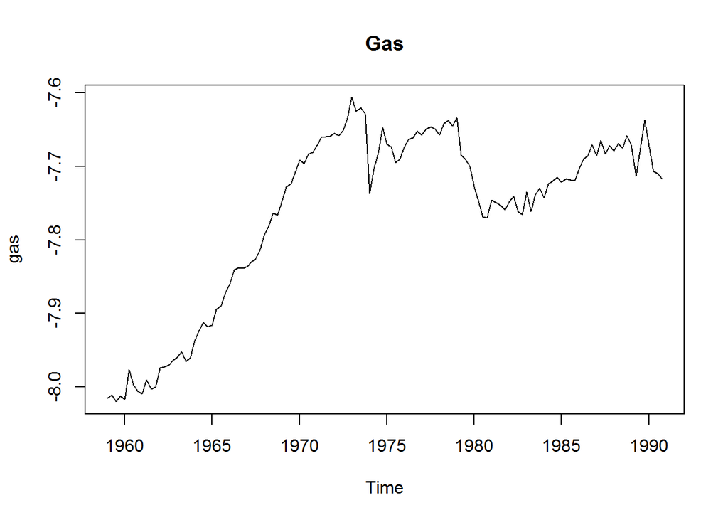

```r
plot(gas, main = "Gas")
```

### Price

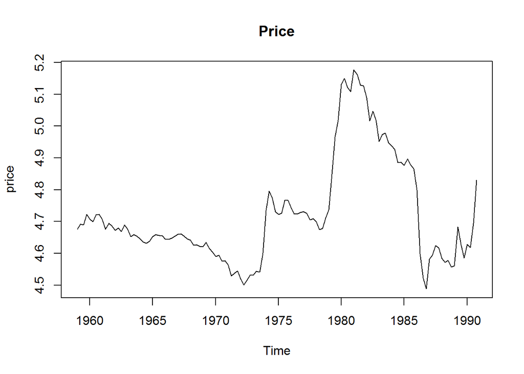

```r
plot(price, main = "Price")
```

### Income

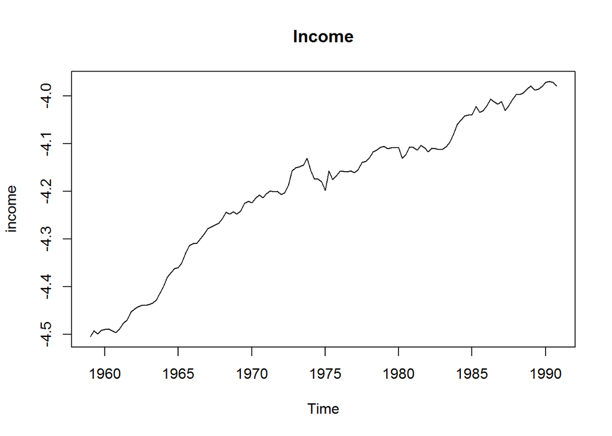

```r
plot(income, main = "Income")
```

### Miles

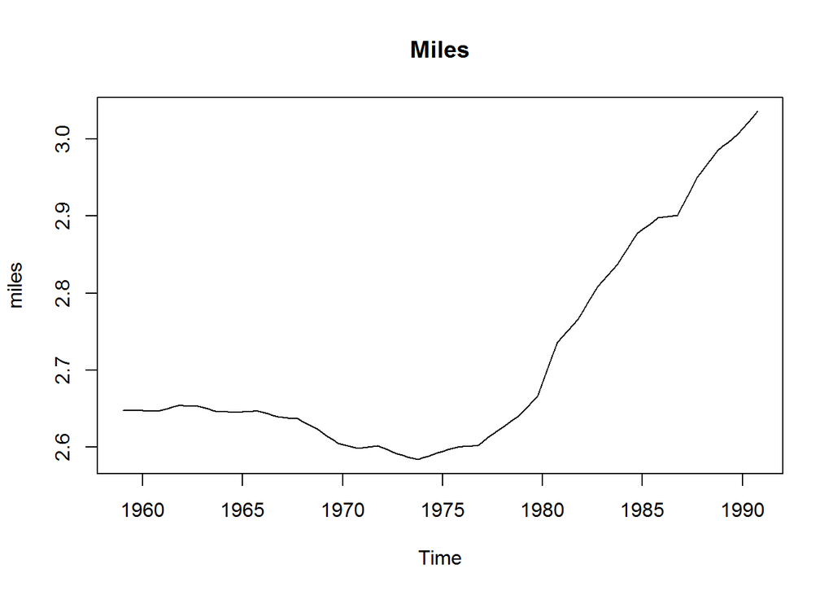

```r
plot(miles, main = "Miles")
```

These are great! Granted we are just using the basic `plot()` function from base R. We could possibly explore some prettier graphs such as Plotly, ggplot2, or others, but for right now, this serves the purpose.

## Autocorrelation and Partial Correlation Plots

We can also generate autocorrelation and partial correlation plots. Also defined as a [correlogram](https://en.wikipedia.org/wiki/Correlogram), these plots allows us to view the time dependencies of the variables of interest, or the correlation between two or more periods of variable observance. **In short** answering the question: “Is an observation related to an adjacent observation?”.

Why is this important? Randomness is one of the four main assumptions that must hold for statistical measurement proccesses. So lets plot them:

Autocorrelation for Gas:

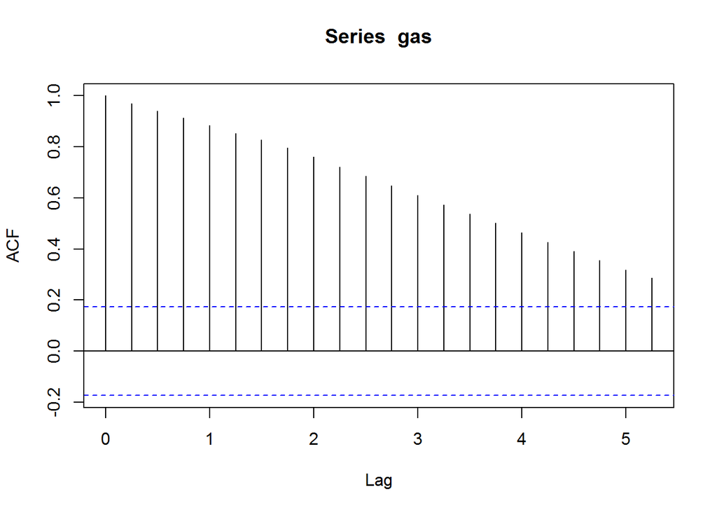

```r
acf(gas)
```

Autocorrelation for Price:

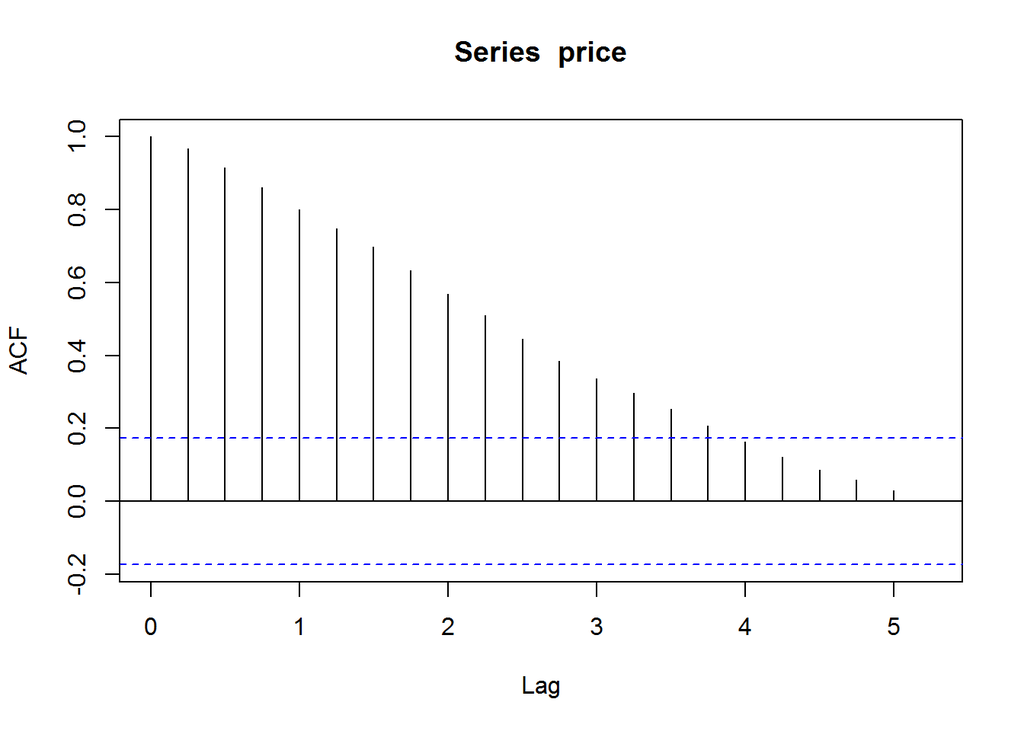

```r
acf(price)
```

# Running Dynamic Models

Now, we can begin constructing the dynamic models and their distributed lag structures. To start simple, let’s define a model such as:

```r
model_1 <- dyn$lm(gas~stats::lag(gas, -1) + price + stats::lag(price, -1))
summary(model_1)
```

```
##
## Call:
## lm(formula = dyn(gas ~ stats::lag(gas, -1) + price + stats::lag(price,
##     -1)))
##
## Residuals:
##       Min        1Q    Median        3Q       Max
## -0.079334 -0.007605 -0.000151  0.008682  0.046476
##
## Coefficients:
##                       Estimate Std. Error t value Pr(>|t|)
## (Intercept)           -0.10678    0.10059  -1.061    0.291
## stats::lag(gas, -1)    0.97827    0.01189  82.267  < 2e-16 ***
## price                 -0.23013    0.03462  -6.648 8.66e-10 ***
## stats::lag(price, -1)  0.21757    0.03467   6.275 5.43e-09 ***
## ---
## Signif. codes:  0 '***' 0.001 '**' 0.01 '*' 0.05 '.' 0.1 ' ' 1
##
## Residual standard error: 0.01602 on 123 degrees of freedom
##   (2 observations deleted due to missingness)
## Multiple R-squared:  0.9822, Adjusted R-squared:  0.9817
## F-statistic:  2258 on 3 and 123 DF,  p-value: < 2.2e-16
```

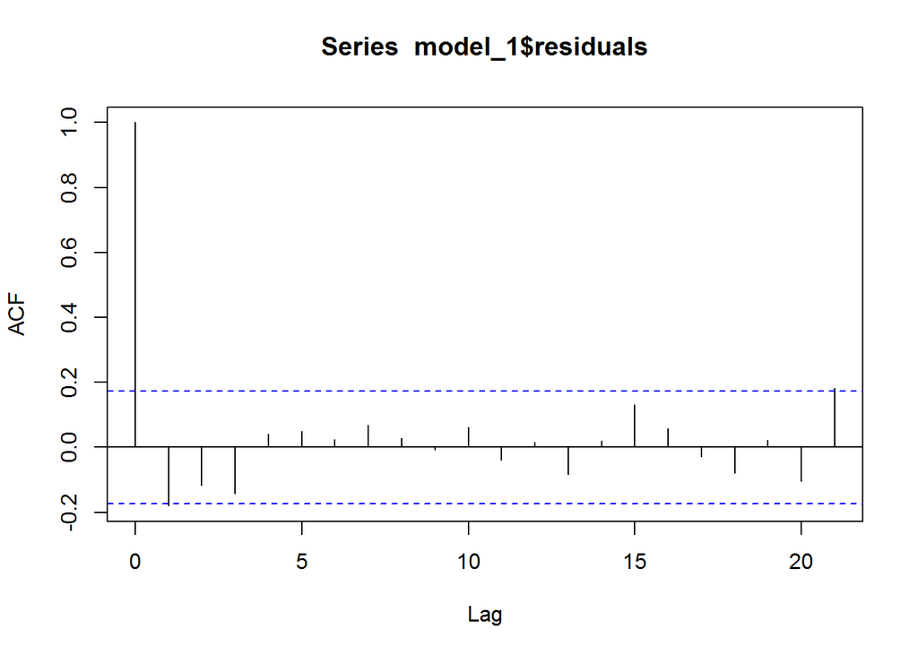

```r
acf(model_1$residuals)
```

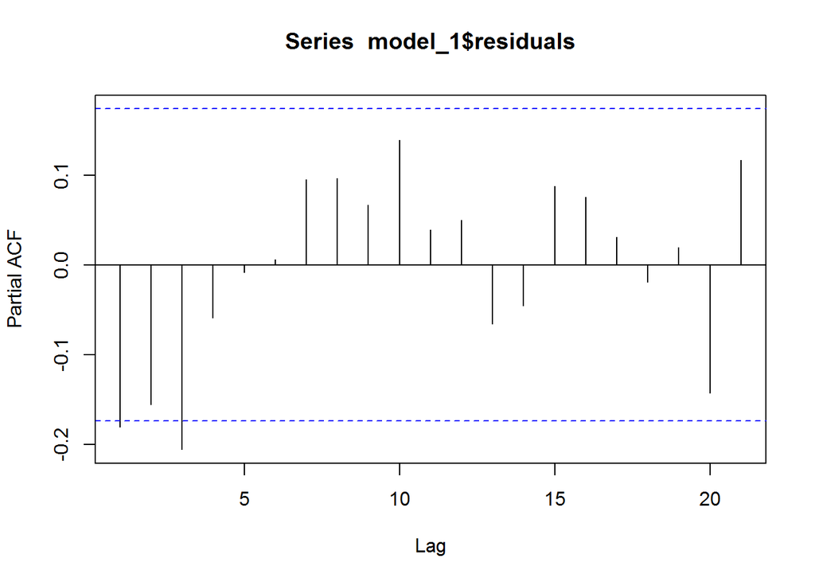

```r
pacf(model_1$residuals)
```

Constructing higher order distributed lag models can also be done! Utilizing the [**dynlm**](https://cran.r-project.org/web/packages/dynlm/dynlm.pdf) package, we can create dynamic models of substantial strucutre without much added complexity:

```r
model_2 <- dynlm(gas ~ L(price, 0:5) + L(income, 0:5) + L(gas, 1:5))
summary(model_2)
```

```
##
## Time series regression with "ts" data:
## Start = 1960(2), End = 1990(4)
##
## Call:
## dynlm(formula = gas ~ L(price, 0:5) + L(income, 0:5) + L(gas,
##     1:5))
##
## Residuals:
##       Min        1Q    Median        3Q       Max
## -0.075543 -0.007502 -0.000365  0.007071  0.041426
##
## Coefficients:
##                  Estimate Std. Error t value Pr(>|t|)
## (Intercept)      0.005543   0.126043   0.044 0.965003
## L(price, 0:5)0  -0.267645   0.037874  -7.067 1.81e-10 ***
## L(price, 0:5)1   0.262869   0.069291   3.794 0.000248 ***
## L(price, 0:5)2  -0.017408   0.075414  -0.231 0.817895
## L(price, 0:5)3  -0.072092   0.077389  -0.932 0.353707
## L(price, 0:5)4   0.014397   0.077210   0.186 0.852445
## L(price, 0:5)5   0.058208   0.046340   1.256 0.211866
## L(income, 0:5)0  0.292773   0.158823   1.843 0.068092 .
## L(income, 0:5)1 -0.162201   0.220227  -0.737 0.463060
## L(income, 0:5)2 -0.049248   0.214371  -0.230 0.818748
## L(income, 0:5)3  0.010408   0.213131   0.049 0.961146
## L(income, 0:5)4  0.084907   0.210131   0.404 0.686984
## L(income, 0:5)5 -0.198963   0.153118  -1.299 0.196647
## L(gas, 1:5)1     0.660575   0.096063   6.876 4.55e-10 ***
## L(gas, 1:5)2     0.067011   0.114535   0.585 0.559754
## L(gas, 1:5)3    -0.023575   0.117094  -0.201 0.840825
## L(gas, 1:5)4     0.132193   0.119014   1.111 0.269222
## L(gas, 1:5)5     0.163127   0.101384   1.609 0.110620
## ---
## Signif. codes:  0 '***' 0.001 '**' 0.01 '*' 0.05 '.' 0.1 ' ' 1
##
## Residual standard error: 0.01506 on 105 degrees of freedom
## Multiple R-squared:  0.9842, Adjusted R-squared:  0.9816
## F-statistic: 383.7 on 17 and 105 DF,  p-value: < 2.2e-16
```

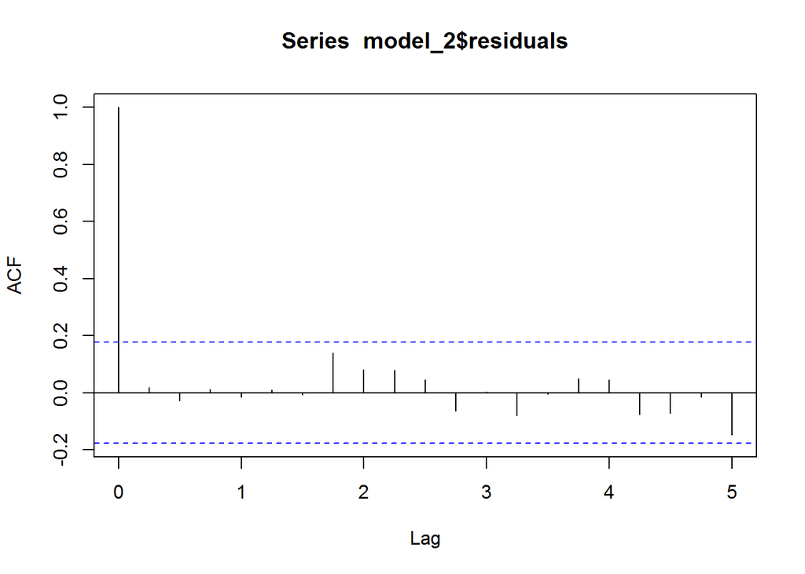

```r
acf(model_2$residuals)
```

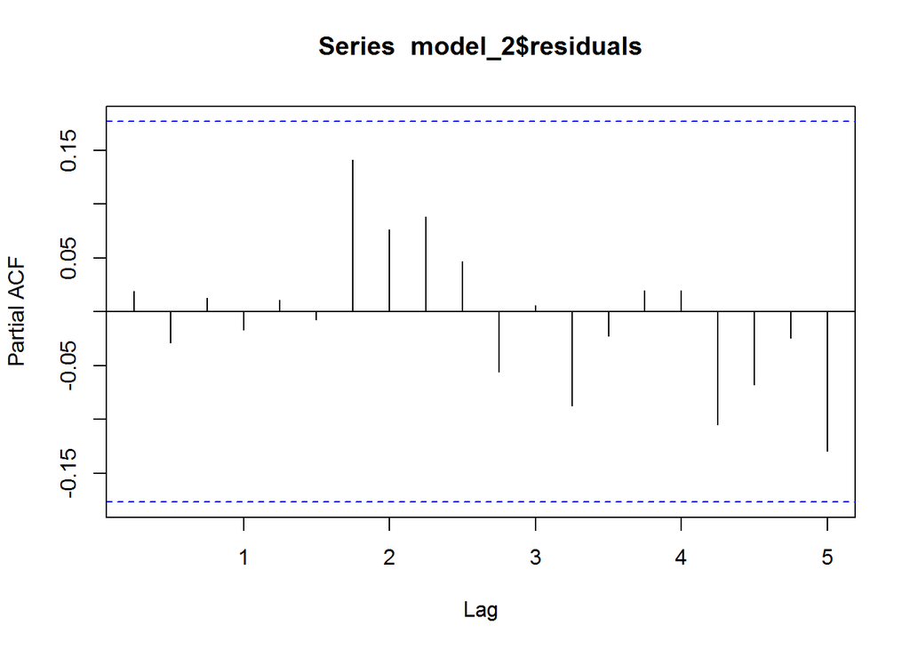

```r
pacf(model_2$residuals)
```

This model is a reproduction of the dynamic model given by Johnston and DiNardo, 1997 ,p. 269, Table 8.5. Note the significance levels and R^2 results of the expanded model.

# Summary:

As we hopefully illustrated, dynamic model are a powerful modeling technique for deriving inference from model containing time dependent variables. Due to the structure of finanical & economic data, model variables are commonly of this structure, so it makes reasonale sense to understand this technique.